# Reproducible Research - Assignment 1

BOZZI Emiliano

Sunday, February 1, 2015

R Markdown file for the 1st peer assessment of the Reproducible Research class.

## Introduction

This assignment makes use of data from a personal activity monitoring device. This device collects data at 5 minute intervals through out the day. The data consists of two months (Oct/Nov 2012) of data from an anonymous individual. The data include the number of steps taken in 5 minute intervals each day.

## Loading and processing the data

```r
unzip('activity.zip')

library('data.table')
activity = fread('activity.csv')
```

Modifying date:

```r
activity$date = as.Date(activity$date)
```

### What is mean total number of steps taken per day?

1. Plotting total number of steps per day

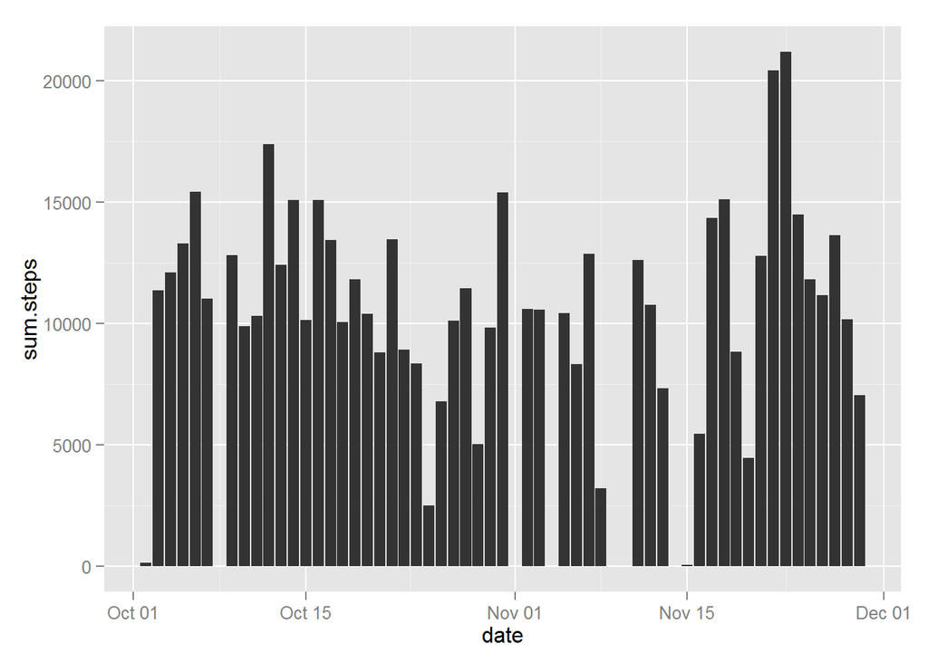

```r
library('ggplot2')
library('dplyr')

activity1 = summarise(group_by(activity, date),
                      sum.steps = sum(steps))

g = ggplot( data = activity1,
            aes(date, sum.steps))
g + geom_bar(stat = 'identity')
```

2. Calculating mean and median of number of steps per day

```r
mean(activity1$sum.steps, na.rm = T)
```

```
## [1] 10766.19
```

```r
median(activity1$sum.steps, na.rm = T)
```

```
## [1] 10765
```

### What is the average daily activity pattern?

1. Making a time series plot of the 5-minute interval and the average number of steps taken, averaged across all days

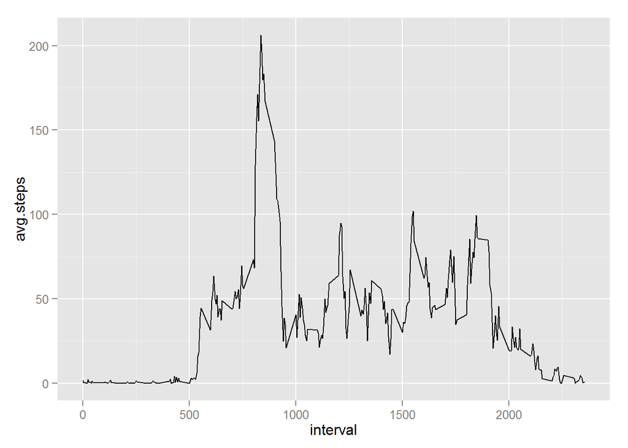

```r
activity2 = summarise(group_by(activity, interval),
                      avg.steps = mean(steps, na.rm = T))
g = ggplot( data = activity2,
            aes(interval, avg.steps))
g + geom_line()
```

2. Finding the 5-mins interval containing, on average across all the days in the dataset, the maximum number of steps

```r
activity2[activity2$avg.steps == max(activity2$avg.steps), ]$interval
```

```
## [1] 835
```

### Imputing missing values

1. Calculating and reporting the total number of missing values in the dataset

```r
sum(is.na(activity$steps))
```

```
## [1] 2304
```

2. Filling in missing values: strategy devising

3. Creating a new dataset that is equal to the original dataset but with the missing data filled in

```r
activity3 = data.frame( date = activity$date,
                        interval = activity$interval,
                        sum.steps = rep(activity1$sum.steps, each = dim(activity2)[1]),
                        avg.steps = rep(activity2$avg.steps, times = dim(activity1)[1]),
                        steps = activity$steps)
index = is.na(activity$steps)
activity3$steps[index] = floor(apply(activity3[,3:4],1,mean, na.rm = T)[index])
activity3 = select(activity3, date, interval, steps)
```

4. Making a histogram of the total number of steps taken each day…

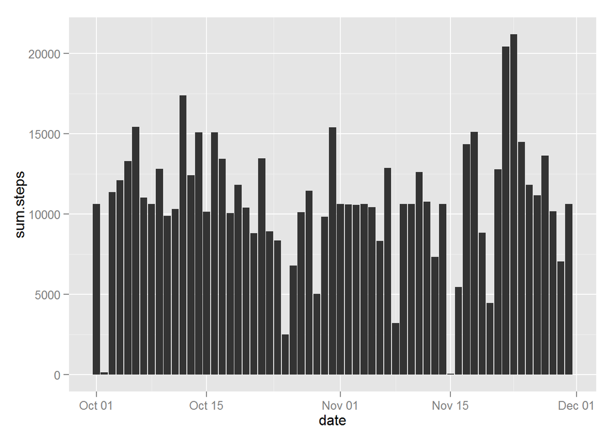

```r
activity4 = summarise(group_by(activity3, date),
                      sum.steps = sum(steps))

g = ggplot( data = activity4,
            aes(date, sum.steps))
g + geom_bar(stat = 'identity')
```

…and Calculating and reporting the mean and median total number of steps taken per day

```r
mean(activity4$sum.steps, na.rm = T)
```

```
## [1] 10749.77
```

```r
median(activity4$sum.steps, na.rm = T)
```

```
## [1] 10641
```

The applied gap filling reduced mean and median values of the total number of steps taken per day by 0.15 % and 1.15 % respectively,

### Are there differences in activity patterns between weekdays and weekends?

1. Modifying the gap filled data set

```r
activity5 = mutate(activity3,
                   weekday = as.factor(weekdays(date)),
                   weekend = as.factor(weekday %in% c('Saturday', 'Sunday')))
```

2. Plotting the time series plot for weekend days and week days

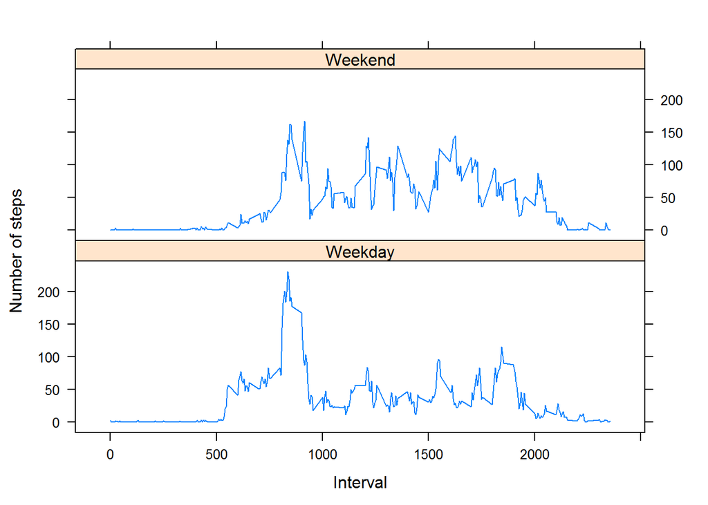

```r
activity6 = summarise(group_by(activity5, interval, weekend),
                      avg.steps = mean(steps, na.rm = T))

library('lattice')
xyplot(avg.steps ~ interval | weekend,
       type = "l",
       ylab = 'Number of steps',
       xlab = 'Interval',
       data = activity6,
       layout = c(1, 2),
       strip = strip.custom(factor.levels = c('Weekday', 'Weekend')))
```